# Homework 1

Author

Ridhi Bandaru

```r
library(tidyverse)
theme_set(theme_bw())
```

## Question 1 [30 Points total]

### Question 1(a) [10 Points]

The iris dataset is available in R by default.

```r
iris |>
  glimpse()
```

```
Rows: 150
Columns: 5
$ Sepal.Length <dbl> 5.1, 4.9, 4.7, 4.6, 5.0, 5.4, 4.6, 5.0, 4.4, 4.9, 5.4, 4.…
$ Sepal.Width  <dbl> 3.5, 3.0, 3.2, 3.1, 3.6, 3.9, 3.4, 3.4, 2.9, 3.1, 3.7, 3.…
$ Petal.Length <dbl> 1.4, 1.4, 1.3, 1.5, 1.4, 1.7, 1.4, 1.5, 1.4, 1.5, 1.5, 1.…
$ Petal.Width  <dbl> 0.2, 0.2, 0.2, 0.2, 0.2, 0.4, 0.3, 0.2, 0.2, 0.1, 0.2, 0.…
$ Species      <fct> setosa, setosa, setosa, setosa, setosa, setosa, setosa, s…
```

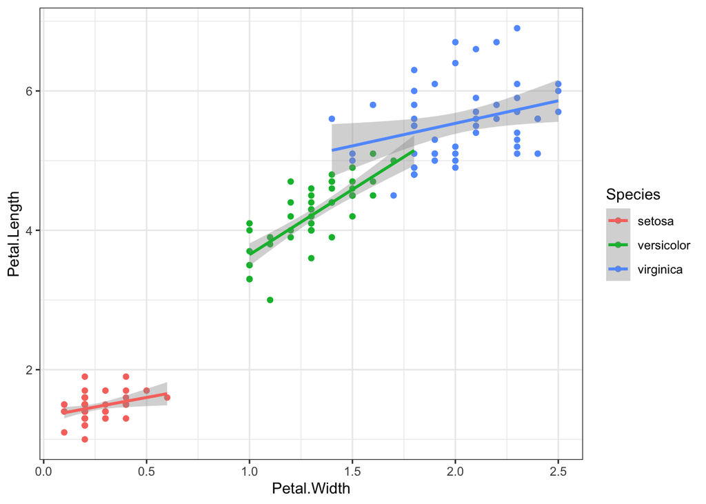

```r
# INSERT SOLUTION HERE

ggplot(data = iris,
       mapping = aes(x = Petal.Width,
                     y = Petal.Length,
                     color = Species)) +
  geom_point() +
  geom_smooth(method = "lm")
```

### Question 1(b) [10 Points]

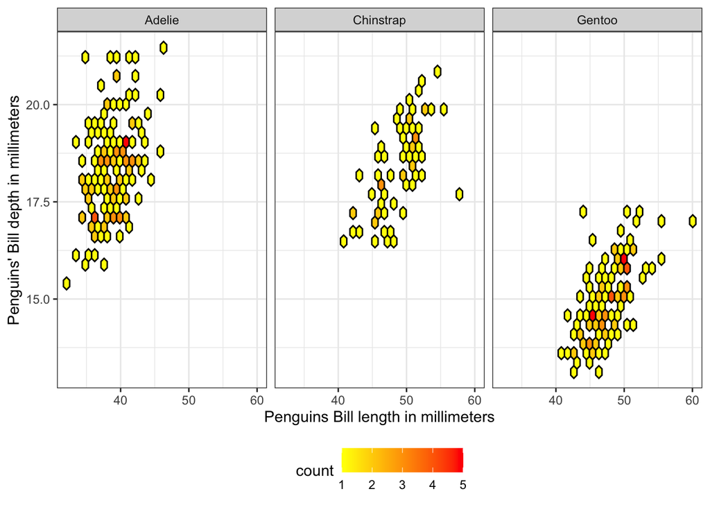

```r
library(palmerpenguins)
library(hexbin)

# INSERT SOLUTION HERE

penguins |>
  ggplot(aes(x = bill_length_mm,
             y = bill_depth_mm)) +
  labs(x = "Penguins Bill length in millimeters",
       y = "Penguins' Bill depth in millimeters") +
  facet_wrap(~species) +
  geom_hex(color = 'black') +
  scale_fill_gradient(low = "yellow",
                      high = "red") +
  theme(legend.position = "bottom")
```

### Question 1(c) [10 Points]

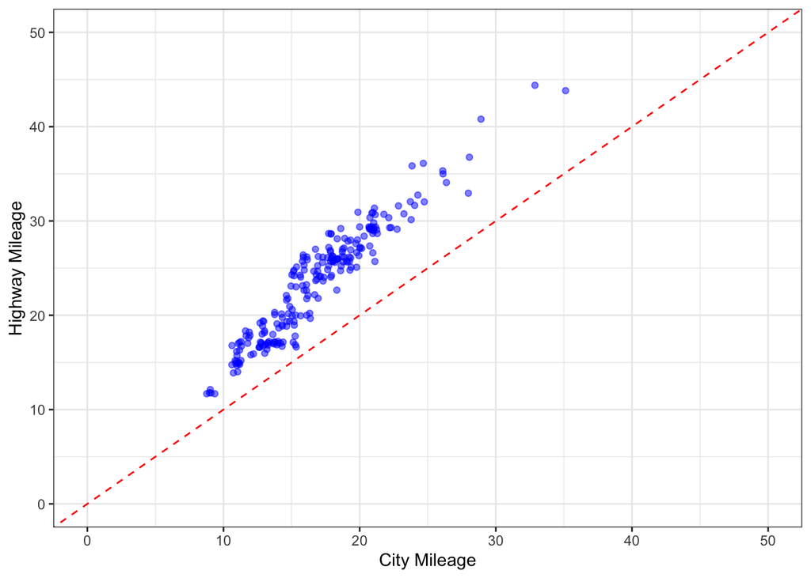

```r
# INSERT SOLUTION HERE

set.seed(1)
ggplot(data = mpg, aes(x = cty, y = hwy)) +
  geom_jitter(color = 'blue',
             alpha = 0.5) +
  xlim(0,50) + ylim(0,50) +
  labs(x = "City Mileage",
       y = "Highway Mileage") +
  geom_abline(slope = 1,
              intercept = 0,
              linetype = "dashed",
              color = 'red')
```

## Question 2 [50 Points Total]

This question will apply to the gapminder dataset, available within the gapminder package on CRAN. Please download and load this package to complete the following questions.

```r
library(gapminder)
```

The function filter() will be helpful for completing these question. Though I’ve referenced it in the class notes a couple of times, we will not fully cover this function until January 23rd. If you want an early start on the homework, see Section 3.2.1 of the book for instructions on how to use filter().

### Question 2(a) [10 Points]

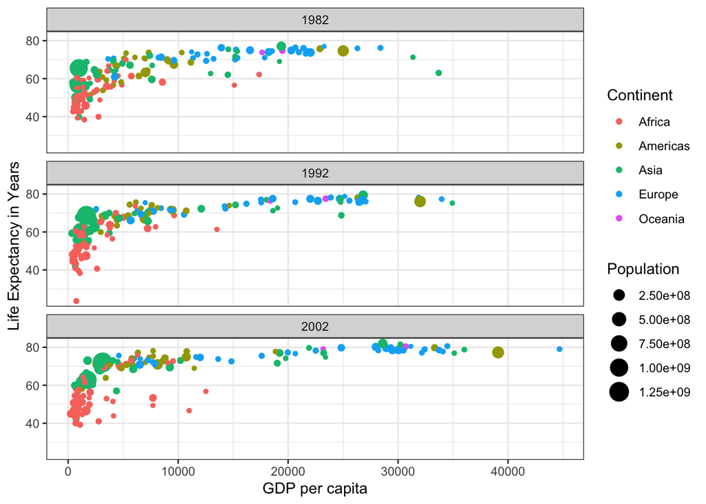

```r
# INSERT SOLUTION HERE
years <- filter(gapminder, year == 1982 | year == 1992 | year == 2002)
years |>
  ggplot(aes(x = gdpPercap,
             y = lifeExp,
             size = pop,
             color = continent)) +
  geom_point() +
  labs(x = "GDP per capita",
       y = "Life Expectancy in Years",
       color = 'Continent',
       size = 'Population') +
  facet_wrap(~year,
             ncol = 1)
```

### Question 2(b) [10 Points]

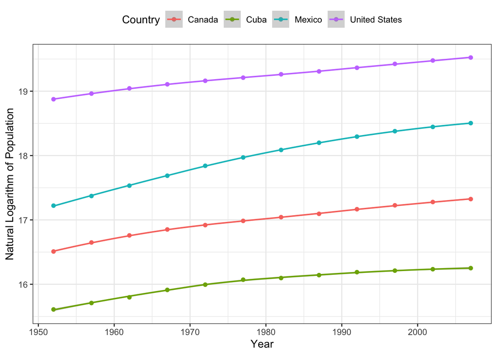

```r
# INSERT SOLUTION HERE

countries <- filter(gapminder, country == 'Canada' | country == 'Cuba' | country == 'Mexico' | country == 'United States')

countries |>
  ggplot(aes(x = year,
             y = log(pop),
             color = country)) +
  geom_point() +
  geom_smooth(size = 0.7) +
  labs(x = "Year",
       y = "Natural Logarithm of Population",
       color = "Country") +
  theme(legend.position = "top")
```

### Question 2(c) [10 Points]

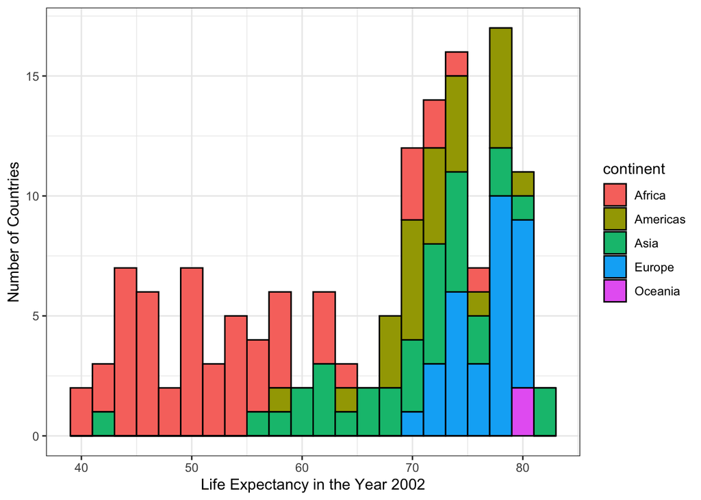

```r
# INSERT SOLUTION HERE

year2002 <- filter(gapminder, year == 2002)
year2002 |>
  ggplot(aes(x = lifeExp, fill = continent)) +
  geom_histogram(binwidth = 2,
                 color = 'black') +
  labs(x = "Life Expectancy in the Year 2002",
       y = "Number of Countries")
```